# Week 14, Lesson 26: Optimization and Maxmimum Likelihood Estimation

AG Schissler

Wednesday November 28, 2018

## I. Opening

### Start-of-class work

1. Log in the your workstation.
2. Open the RStudio application on your machine.
3. Open lesson26_mle_optim.Rmd from website so that you can work along the lecture.

### This week’s agenda

Digging into more computational methods of inference and computation, including

1. Jacknife
2. Bootstrap
3. Maximum Likelihood Estimation

## II. Numerical optimization

From Braun and Murdock 2018, *A First Course in Statistical Programming with R*, there are many areas of statistics and applied mathematics that asks: given a function $f(\cdot)$, which value of $x$ makes $f(x)$ as large or small as possible?

I’ll discuss one simple optimization method in detail, then show you tools for more complex and efficient algorithms.

### The golden section search method

The golden section search method is a simple way of finding the minimizer of a single-variable function which has single minimizer is $[a,b]$. Consider minimizing the function

$$f(x) = |x - 3.5| + (x - 2)^2$$

In R,

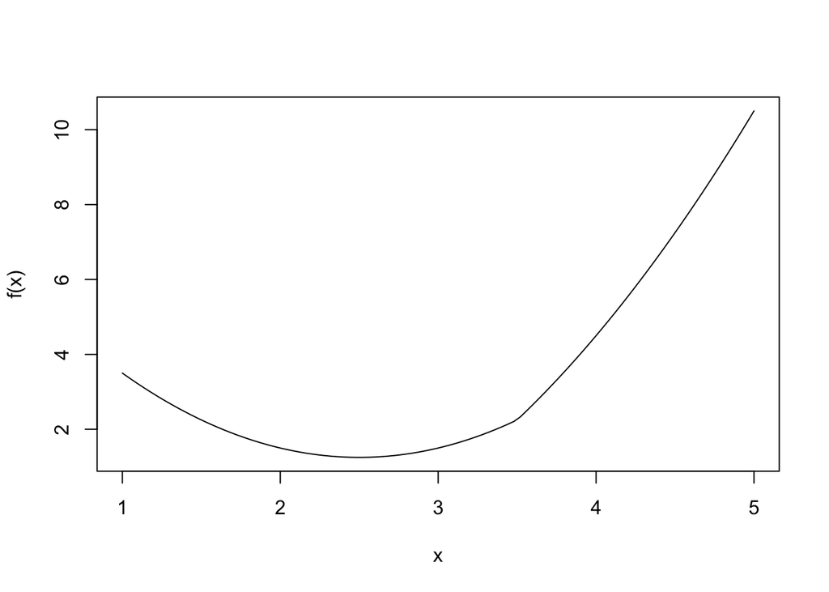

```r
f <- function(x){
    abs(x - 3.5) + (x -2 )^2
}
curve(f, from = 1, to = 5)
```

The golden search method is an interative method, which involves the following steps:

1. Start with the interval $[a,b]$, known to contain the minimizer.
2. Repeatedly shrink it, finding smaller and smaller intervals $[a^\prime,b^\prime]$ which still contains the minimzer.
3. Stop when $b^\prime - a^\prime$ is small enough (when the length is smaller than a pre-set tolerance).

The minimzer is then given as the midpoint of the final interval. The maximum error = $(b^\prime - a^\prime) / 2$.

The algorithm makes use of the golden ratio,

$$\phi = \frac{1 + \sqrt{5}}{2}.$$

Note that $1/\phi = \phi - 1$ and $1/\phi^2 = 1 - 1/\phi$.

Two reasons for this;

1. It makes the selection of “probe points” efficient, by avoiding selecting wide intervals. You can learn more about this at the [wiki](https://en.wikipedia.org/wiki/Golden-section_search) page. This leads to rapid convergence.
2. When the ratio is judiciously used, you don’t have to re-evaluate the function multiple times. For example, if you locate interior points at $x_1 = b-(b-a)/\phi$ and $x_2 = a + (b-a)/\phi$ then

$$\begin{align}
x_1^{\prime} &= b - (b-a^{\prime})/\phi \\
&= b - (b-x_1)/\phi \\
&= b - (b-a)/\phi^2 \\
&= a + (b -a)/\phi \\
&= x_2
\end{align}$$

```r
golden <- function(f, a, b, tol = 1e-7) {
    ratio <- 2 / (sqrt(5) + 1) ## 1/phi, aka "silver ratio".
    x1 <- b - ratio * (b - a)
    x2 <- a + ratio * (b - a)

    f1 <- f(x1)
    f2 <- f(x2)

    while(abs(b - a) > tol){
        if (f2 > f1){
            b <- x2
            x2 <- x1
            f2 <- f1
            x1 <- b - ratio * (b - a)
            f1 <- f(x1)
        } else{
            a <- x1
            x1 <- x2
            f1 <- f2
            x2 <- a + ratio * (b - a)
            f2 <- f(x2)
        }
    }
    return( (a + b) / 2 )
}
```

```r
golden(f, 1, 5)
```

```
## [1] 2.5
```

### Two other important methods

- Newton-Raphson
- The Nelder-Mead simplex method (several variables)

### Built-in R functions

For one-dimensional optimization, the `optimize()` function performs a variation of the golden section search. For multi-dimensional problems `optim()` is a general purpose wrapper for several optimization routines including variants of Newton-Raphson and Nelder-Mead. In practice, the choice of optimizer should not matter much. You can try several and investigate any differences.

## III. Maxmimum Likelihood Estimation

From Rizzo 2006, Maximum likelihood is a method of estimating parameters from a distribution. The abbreviation MLE may refer to the method, to the estimate, or to the estimator. The method finds a value of the parameter that maximizes the *likelihood function*. So numerical optimization of the likelihood function is an important problem in statistics.

Suppose that $X_1, \ldots, X_n$ are random variables with parameter $\theta \in \Theta$ ($\theta$ may be a vector). The likelihood function $L(\theta)$ of random variables $X_1, \ldots, X_n$ evaluated at observed values $x_1, \ldots, x_n$ is defined as the joint density

$$L(\theta) = f(x_1,\ldots,x_n | \theta).$$

If $X_1, \ldots, X_n$ are a random sample (so $X_i$ are iid) with common density $f(x|\theta)$, then

$$L(\theta) = \prod^n_{i=1} f(x_i|\theta).$$

A maximum likelihood estimate of $\theta$ is a value $\hat{\theta}$ that maximizes $L(\theta)$. That is, $\hat{\theta}$ is a solution (not necessarily unique) to

$$L(\hat{\theta}) = f(x_1,\ldots,x_n | \hat{\theta}) = \max_{\theta \in \Theta} f(x_1,\ldots,x_n | \theta).$$

One finds the MLE is a standard way, finding critical points through solving the equation

$$\frac{d}{d\theta} L(\theta) = 0.$$

In practice, instead of solving the above equation, we typically solve

$$\frac{d}{d\theta} l(\theta) = 0.$$

where $l(\theta) = log L(\theta)$, where $log(x)$ is the natural log. $l(\theta)$ is called the *log-likelihood* and is much easier to compute with (product becomes a sum).

### Example (MLE using `mle` function for exponentional RV)

Suppose $Y_1,Y_2$ are iid with density $f(y)= \theta e^{-\theta y}, y > 0$. Find the MLE of $\theta$.

By independence,

$$L(\theta) = (\theta e^{-\theta y_1}) (\theta e^{-\theta y_2}) = \theta^2 e^{-\theta(y_1+y_2)}.$$

Then $l(\theta)=2log\theta-\theta(y_1+y_2)$. So we have

$$\frac{d}{d\theta} l(\theta) = \frac{2}{\theta} - (y_1+y_2) = 0, \theta > 0.$$

The unique solution is $\hat{\theta} = 2/(y_1+y_2)$. Notice this is the reciprocal of the mean (since $\theta$ is the rate parameter, this should make sense).

Now let’s find the mle using the `mle` function from the `stats4` package. `mle` is a nice wrapper around `optim`.

```r
## observed sample
y <- c(0.04304550, 0.50263474)

## mle takes in the minus log-likelihood as the function to optimize.
mlogL <- function(theta=1) {
    ## minus log-likelihood of exp. density, rate is 1/theta
    ## notice that the function below is for n = length(y) observations
    return( - (length(y) * log(theta) - theta * sum(y)) )
}

require(stats4)
fit <- stats4::mle(mlogL)
summary(fit)
```

```
## Maximum likelihood estimation
##
## Call:
## stats4::mle(minuslogl = mlogL)
##
## Coefficients:
##       Estimate Std. Error
## theta  3.66515   2.591652
##
## -2 log L: -1.195477
```

Alternatively, you can provide initial values for the optimizer.

```r
stats4::mle(mlogL, start = list(theta=1))
```

```
##
## Call:
## stats4::mle(minuslogl = mlogL, start = list(theta = 1))
##
## Coefficients:
##   theta
## 3.66515
```

```r
stats4::mle(mlogL, start = list(theta=mean(y)))
```

```
##
## Call:
## stats4::mle(minuslogl = mlogL, start = list(theta = mean(y)))
##
## Coefficients:
##   theta
## 3.66515
```

### Comments

For commonly used distributions (e.g. normal), the log-likelihood are well known and can be found by searching online for a few minutes. For less common distributions, you’ll have to derive the MLE and check that there exists a unique solution. Check the second derivative and boundaries!

## IV. Continue working on Lab 8, time permitting